# HW1

jiaying Ning

2/15/2021

In this exercise, we will predict solubility of compounds using their chemical structures.

Among the 228 predictors, 208 are binary variables that indicate the presence or absence of a particular chemical substructure, 16 are count features, such as the number of bonds or the number of bromine atoms, and 4 are continuous features, such as molecular weight or surface area.

```r
#load package
library(pls)
library(readxl)
library(glmnet)
```

```r
library(plotmo)
library(dplyr)
```

### Load Data

```r
training = read.csv("./data/solubility_train.csv")
test = read.csv("./data/solubility_test.csv")
```

### (a) Fit a linear model using least squares on the training data and calculate the meansquared error using the test data.

```r
LinearMod <- lm(Solubility ~ .,
                data = training)
```

```r
 pred_lm <- predict(LinearMod, test)
 mean((test$Solubility - pred_lm)^2)
```

```
## [1] 0.5558898
```

**MSE is 0.5558898**

### (b) Fit a ridge regression model on the training data, with lambda chosen by cross-validation.Report the test error.

```r
training2 <- model.matrix(Solubility ~ ., training)[ ,-1]
test2 = model.matrix(Solubility ~ ., test)[ ,-1]
y <- training$Solubility
```

chose lambda by cross-validation

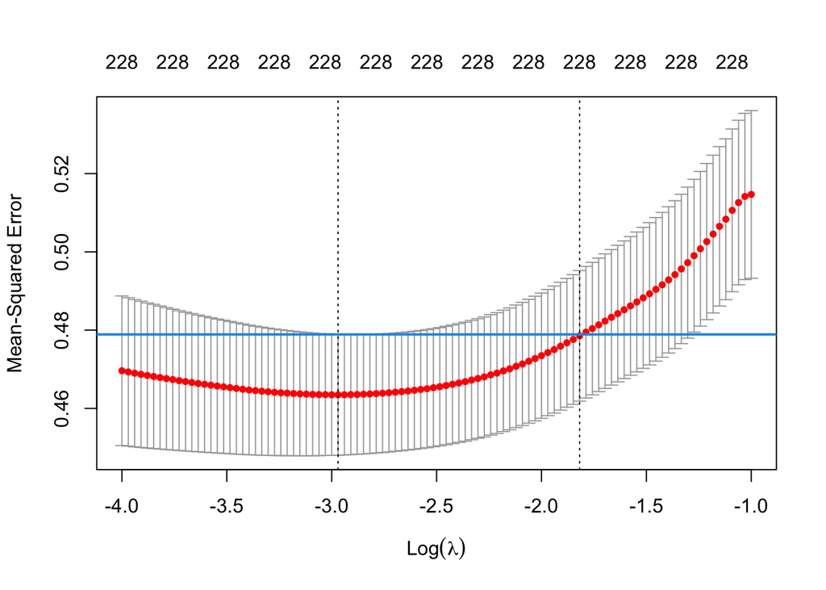

```r
set.seed(2761)
cv.ridge <- cv.glmnet(training2, y,
                      alpha = 0,
                      lambda = exp(seq(-1, -4, length = 100)))

plot(cv.ridge)
abline(h = (cv.ridge$cvm + cv.ridge$cvsd)[which.min(cv.ridge$cvm)], col = 4, lwd = 2)
```

```r
# min CV MSE
cv.ridge$lambda.min
```

```
## [1] 0.05131886
```

```r
# the 1SE rule
cv.ridge$lambda.1se
```

```
## [1] 0.1623206
```

fit chosen lambda into model to get the optimal coefficients

```r
predict(cv.ridge, s = cv.ridge$lambda.min, type = "coefficients")
```

```
## 229 x 1 sparse Matrix of class "dgCMatrix"
##                              1
## (Intercept)        8.482937794
## FP001              0.027048873
## FP002              0.160012714
## FP003             -0.097511253
## FP004             -0.273559020
## FP005             -0.006859269
## FP006             -0.138289006
## FP007              0.016517425
## FP008              0.063296492
## FP009              0.025050078
## FP010              0.119795059
## FP011              0.135615594
## FP012             -0.087744694
## FP013             -0.105092468
## FP014              0.043502519
## FP015             -0.102103536
## FP016             -0.135117289
## FP017             -0.224373852
## FP018             -0.230240946
## FP019             -0.032688035
## FP020              0.177638776
## FP021             -0.009654390
## FP022              0.152648899
## FP023             -0.228192674
## FP024             -0.224463441
## FP025              0.073968837
## FP026              0.185960658
## FP027              0.239750243
## FP028              0.084877598
## FP029             -0.063200263
## FP030             -0.206849590
## FP031              0.178728464
## FP032             -0.375454001
## FP033              0.480605744
## FP034             -0.173816381
## FP035             -0.211880161
## FP036              0.011901731
## FP037              0.290134347
```

[output cut: 176 more lines]

```
## NumMultBonds      -0.122365929
## NumRotBonds       -0.254377966
## NumDblBonds       -0.037412442
## NumAromaticBonds  -0.178426390
## NumHydrogen        0.135624797
## NumCarbon         -0.317537797
## NumNitrogen        0.450013718
## NumOxygen          0.518605297
## NumSulfer         -0.851496808
## NumChlorine       -0.941360725
## NumHalogen        -0.590368732
## NumRings          -0.401983162
## HydrophilicFactor  0.102481756
## SurfaceArea1       0.110000625
## SurfaceArea2       0.060086415
```

```r
# make prediction
ridge_pred=(predict(cv.ridge, newx = test2,
             s = "lambda.min", type = "response"))

mean((ridge_pred - test$Solubility)^2)
```

```
## [1] 0.5148783
```

**test error is 0.5148783**

### (c) Fit a lasso model on the training data, with lambda chosen by cross-validation. Report the test error and the number of non-zero coeficient estimates in your model.

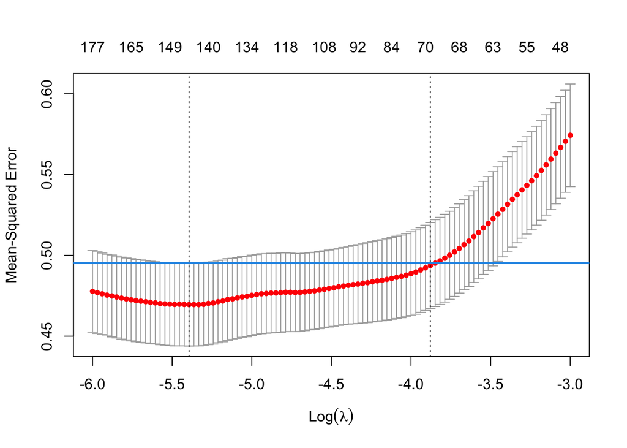

```r
cv.lasso <- cv.glmnet(training2, y,
                      alpha = 1,
                      lambda = exp(seq(-3, -6, length = 100)))
plot(cv.lasso)
abline(h = (cv.lasso$cvm + cv.lasso$cvsd)[which.min(cv.lasso$cvm)], col = 4, lwd = 2)
```

```r
cv.lasso$lambda.min
```

```
## [1] 0.004544037
```

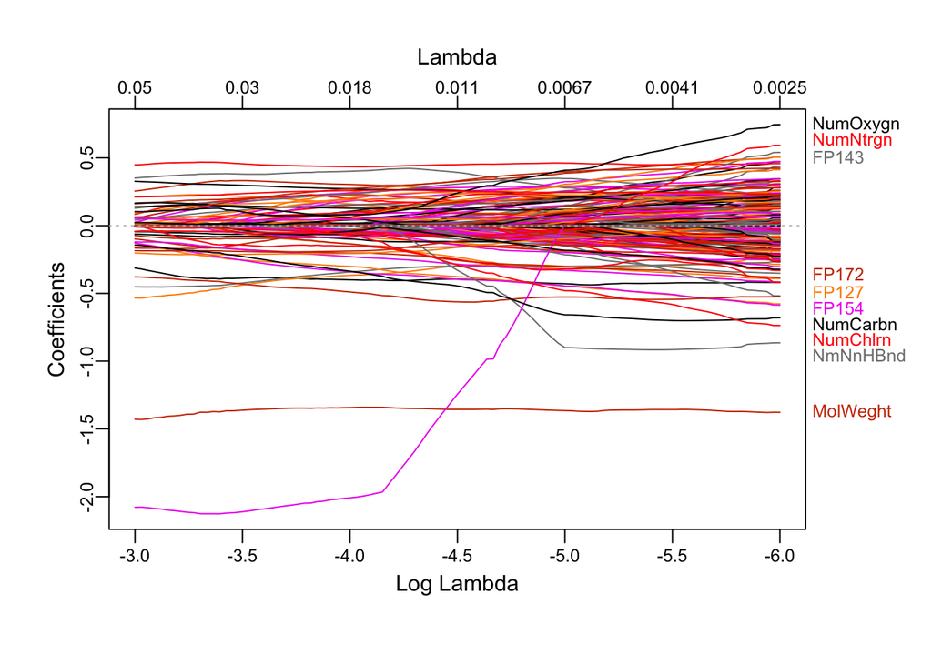

```r
plot_glmnet(cv.lasso$glmnet.fit)
```

```r
Lasso_coe = predict(cv.lasso, s = "lambda.min", type = "coefficients")

final_parameter=which(Lasso_coe[,1] != 0)
final_parameter
```

```
##      (Intercept)            FP002            FP003            FP004
##                1                3                4                5
##            FP006            FP012            FP013            FP015
##                7               13               14               16
##            FP016            FP017            FP018            FP020
##               17               18               19               21
##            FP023            FP024            FP026            FP027
##               24               25               27               28
##            FP030            FP031            FP033            FP034
##               31               32               34               35
##            FP035            FP037            FP038            FP039
##               36               38               39               40
##            FP040            FP043            FP044            FP045
##               41               44               45               46
##            FP049            FP050            FP053            FP054
##               50               51               54               55
##            FP055            FP057            FP059            FP061
##               56               58               60               62
##            FP063            FP064            FP065            FP066
##               64               65               66               67
##            FP068            FP069            FP070            FP071
##               69               70               71               72
##            FP073            FP074            FP075            FP076
##               74               75               76               77
##            FP077            FP078            FP079            FP080
##               78               79               80               81
##            FP081            FP082            FP083            FP084
##               82               83               84               85
##            FP085            FP086            FP088            FP090
##               86               87               89               91
##            FP091            FP093            FP094            FP096
##               92               94               95               97
##            FP098            FP099            FP102            FP103
##               99              100              103              104
##            FP104            FP105            FP106            FP109
##              105              106              107              110
##            FP111            FP112            FP113            FP116
##              112              113              114              117
##            FP118            FP119            FP120            FP122
##              119              120              121              123
```

[output cut: 19 more lines]

```
##              175              177              181              182
##            FP182            FP184            FP186            FP187
##              183              185              187              188
##            FP188            FP190            FP191            FP192
##              189              191              192              193
##            FP198            FP201            FP202            FP203
##              199              202              203              204
##            FP206        MolWeight         NumAtoms     NumNonHBonds
##              207              210              211              214
##     NumMultBonds      NumRotBonds NumAromaticBonds      NumHydrogen
##              215              216              218              219
##        NumCarbon      NumNitrogen        NumOxygen        NumSulfer
##              220              221              222              223
##      NumChlorine         NumRings     SurfaceArea1
##              224              226              228
```

```r
Lasso_pred=predict(cv.lasso, newx = test2, s = "lambda.min", type = "response")

mean((Lasso_pred - test$Solubility)^2)
```

```
## [1] 0.4992432
```

### (d) Fit a principle component regression model on the training data, with M chosen by cross-validation. Report the test error and the value ofM selected by cross-validation.

```r
set.seed(2)
pcr.mod <- pcr(Solubility ~ .,
               data = training,
               scale = TRUE,
               validation = "CV")

summary(pcr.mod)
```

```
## Data:    X dimension: 951 228
##  Y dimension: 951 1
## Fit method: svdpc
## Number of components considered: 228
##
## VALIDATION: RMSEP
## Cross-validated using 10 random segments.
##        (Intercept)  1 comps  2 comps  3 comps  4 comps  5 comps  6 comps
## CV           2.048    2.045     1.98    1.717    1.618    1.585    1.453
## adjCV        2.048    2.044     1.98    1.716    1.608    1.615    1.452
##        7 comps  8 comps  9 comps  10 comps  11 comps  12 comps  13 comps
## CV       1.296    1.293    1.296     1.273     1.250     1.250     1.248
## adjCV    1.292    1.291    1.295     1.271     1.245     1.248     1.248
##        14 comps  15 comps  16 comps  17 comps  18 comps  19 comps  20 comps
## CV        1.201     1.179     1.120     1.072     1.060     1.049     1.033
## adjCV     1.199     1.181     1.117     1.067     1.058     1.046     1.025
##        21 comps  22 comps  23 comps  24 comps  25 comps  26 comps  27 comps
## CV        1.020     1.017    0.9871    0.9850    0.9839    0.9744    0.9717
## adjCV     1.017     1.018    0.9832    0.9822    0.9817    0.9705    0.9683
##        28 comps  29 comps  30 comps  31 comps  32 comps  33 comps  34 comps
## CV       0.9655    0.9673    0.9729    0.9505    0.9444    0.9252    0.9254
## adjCV    0.9635    0.9650    0.9730    0.9504    0.9387    0.9208    0.9227
##        35 comps  36 comps  37 comps  38 comps  39 comps  40 comps  41 comps
## CV       0.9130    0.8987    0.8899    0.8918    0.8950    0.8863    0.8812
## adjCV    0.9093    0.8957    0.8861    0.8895    0.8951    0.8821    0.8788
##        42 comps  43 comps  44 comps  45 comps  46 comps  47 comps  48 comps
## CV       0.8784    0.8701    0.8633    0.8606    0.8605    0.8545    0.8545
## adjCV    0.8773    0.8719    0.8589    0.8554    0.8581    0.8509    0.8515
##        49 comps  50 comps  51 comps  52 comps  53 comps  54 comps  55 comps
## CV       0.8572    0.8586    0.8481    0.8469    0.8469    0.8445    0.8441
## adjCV    0.8545    0.8561    0.8470    0.8420    0.8435    0.8406    0.8415
##        56 comps  57 comps  58 comps  59 comps  60 comps  61 comps  62 comps
## CV       0.8409    0.8377    0.8334    0.8291    0.8245     0.814    0.8108
## adjCV    0.8390    0.8374    0.8346    0.8290    0.8229     0.806    0.8049
##        63 comps  64 comps  65 comps  66 comps  67 comps  68 comps  69 comps
## CV       0.8105    0.8121    0.8128    0.8142    0.8114    0.8114    0.8097
## adjCV    0.8055    0.8074    0.8085    0.8102    0.8067    0.8078    0.8063
##        70 comps  71 comps  72 comps  73 comps  74 comps  75 comps  76 comps
## CV       0.8060    0.8022    0.7986    0.7980    0.7998    0.8025    0.8031
## adjCV    0.8044    0.8020    0.7923    0.7917    0.7951    0.7985    0.7990
```

[output cut: 176 more lines]

```
##             201 comps  202 comps  203 comps  204 comps  205 comps  206 comps
## X               99.94      99.94      99.95      99.95      99.96      99.96
## Solubility      93.35      93.42      93.42      93.42      93.48      93.57
##             207 comps  208 comps  209 comps  210 comps  211 comps  212 comps
## X               99.97      99.97      99.97      99.98      99.98      99.98
## Solubility      93.57      93.65      93.69      93.70      93.70      93.73
##             213 comps  214 comps  215 comps  216 comps  217 comps  218 comps
## X               99.99      99.99      99.99      99.99      99.99      99.99
## Solubility      93.73      93.76      93.78      93.82      93.88      93.90
##             219 comps  220 comps  221 comps  222 comps  223 comps  224 comps
## X              100.00     100.00     100.00     100.00     100.00     100.00
## Solubility      93.92      93.93      93.94      93.97      94.04      94.04
##             225 comps  226 comps  227 comps  228 comps
## X              100.00     100.00     100.00     100.00
## Solubility      94.16      94.16      94.16      94.46
```

```r
cv.mse <- RMSEP(pcr.mod)
ncomp.cv <- which.min(cv.mse$val[1,,])-1
ncomp.cv
```

```
## 157 comps
##       157
```

The value M selected by CV is 157 since it has the samllest mean squared error

```r
predy2.pcr <- predict(pcr.mod, newdata = test,
                      ncomp = ncomp.cv)
# test MSE
mean((test$Solubility - predy2.pcr)^2)
```

```
## [1] 0.549917
```

**test error is 0.549917 and the value of M selected by cross-validation is 157**

### (e) Which model will you choose for predicting solubility?

According to the test error:

both ridge and lasso has relatively low test error compare to the rest of model, and I would agree applying regularization is appropriate since our data has relatively large number of predictors. Between Ridge and Lasso, I would prefer to use Lasso model. Lasso model not only give us a smaller test error, but also provide a “model selection” effect on current model so that we can continue further analyses with a simpler model, this is especially beneficial when a complex model like this is given to us.